# TP: Imputation de données manquantes

```
                              Lilia HARIRECHE - MLDS FA
```

# 1. Dataset: Papillon

## (1) Chargement du dataset et pré-traitement

```r
library(Hmisc)
```

```r
papillons <- read.table('papillons.txt', header=TRUE, row.names='num')
```

**création de données manquantes**

La fonction ci dessous permet de créer les données manquantes avec différents ratios.

```r
get_missing_values <- function(data, test.ratio){

  IND=which(!is.na(data),arr.ind=TRUE)
  ntest=ceiling(dim(data)[1]*dim(data)[2]*test.ratio)
  ind.test=IND[sample(1:dim(IND)[1],ntest),]
  # Création des données manquantes
  dat.test=data[ind.test]
  dat.train=data
  dat.train[ind.test]=NA
  return(dat.train)

}
```

## (2) Génération des tableaux avec données manquantes

```r
papillon_NA_5  <- get_missing_values(papillons,0.05)
papillon_NA_15 <- get_missing_values(papillons,0.15)
papillon_NA_20 <- get_missing_values(papillons,0.20)
papillon_NA_25 <- get_missing_values(papillons,0.25)
papillon_NA_30 <- get_missing_values(papillons,0.30)
```

## (3) Imputation par la moyenne

```r
papillon_moy_5 = impute(papillon_NA_5, fun=mean)
pca_papillon_moy_5 = PCA(papillon_moy_5)
```

Nous remarquons que l’utilisation de *impute()* renvoit une erreur, pour cela nous avons opté pour l’utilisation de *simple.impute()*

```r
library(useful)
```

```r
papillon_moy_5 = simple.impute.data.frame(papillon_NA_5, fun=mean)
papillon_moy_15 = simple.impute.data.frame(papillon_NA_15, fun=mean)
papillon_moy_20 = simple.impute.data.frame(papillon_NA_20, fun=mean)
papillon_moy_25 = simple.impute.data.frame(papillon_NA_25, fun=mean)
papillon_moy_30 = simple.impute.data.frame(papillon_NA_30, fun=mean)
```

Les datasets ci dessus sont obtenus après imputation par la moyenne.

## (4) Application de l’ACP (moyenne)

```r
library(FactoMineR)
library(cowplot)  # plot.PCA
```

- Appliquer l’ACP sur le jeu de données papillons

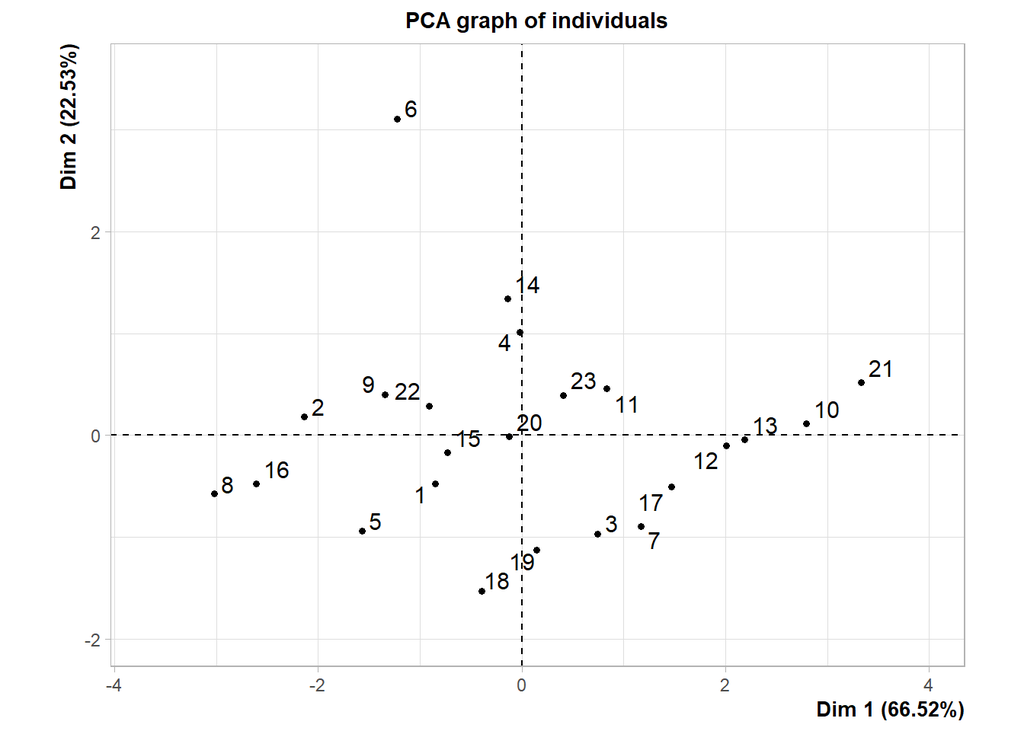

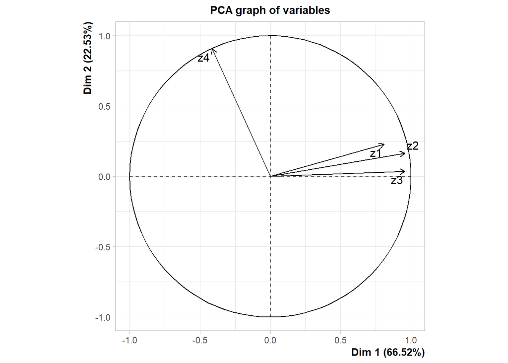

```r
pca = PCA(papillons)
```

- La fonction *pca.compare.plot()* créée ci dessous, permet de comparer entre les différents plans factoriels après réalisation de l’ACP sur chaque tableau complété dans la partie suivante.

```r
pca.compare.plot <- function(pca, pca.completed, titre){

  fig1 <- plot.PCA(pca, label='none', title='PCA of the original data')
  fig2 <- plot.PCA(pca.completed, label='none', title = titre)
  plot_grid(fig1, fig2, labels = "AUTO")

}
```

- Réalisons l’ACP et appliquond la fonction créée précedemment, ce qui permet de comparer entre Le plan factoriel de dataset original avec ceux des tableaux complétés.

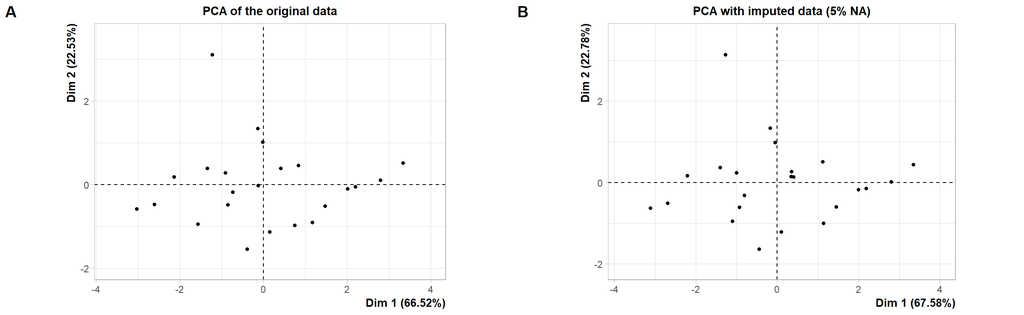

```r
pca_papillon_moy_5 = PCA(papillon_moy_5, graph=FALSE)
pca.compare.plot(pca,pca_papillon_moy_5, 'PCA with imputed data (5% NA)')
```

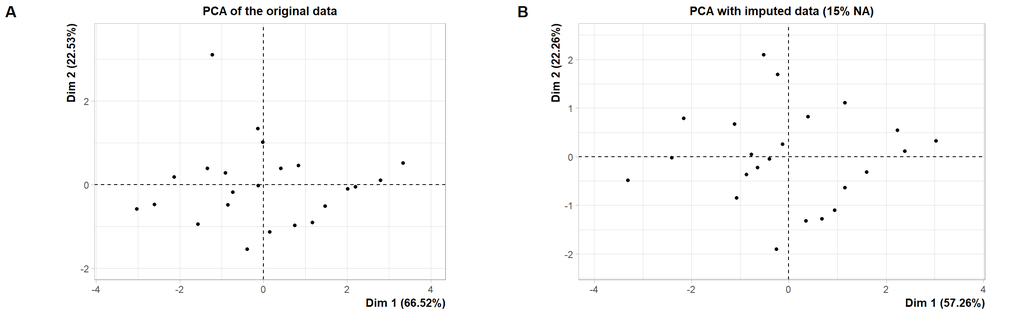

```r
pca_papillon_moy_15 = PCA(papillon_moy_15, graph=FALSE)
pca.compare.plot(pca,pca_papillon_moy_15, 'PCA with imputed data (15% NA)')
```

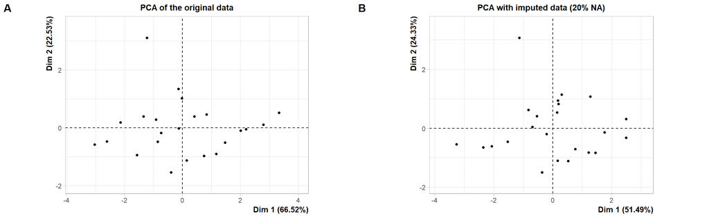

```r
pca_papillon_moy_20 = PCA(papillon_moy_20, graph=FALSE)
pca.compare.plot(pca,pca_papillon_moy_20, 'PCA with imputed data (20% NA)')
```

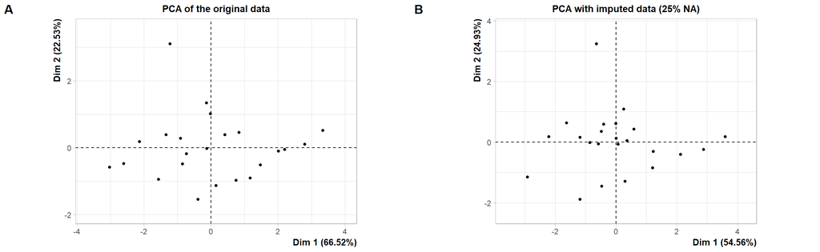

```r
pca_papillon_moy_25 = PCA(papillon_moy_25, graph=FALSE)
pca.compare.plot(pca,pca_papillon_moy_25, 'PCA with imputed data (25% NA)')
```

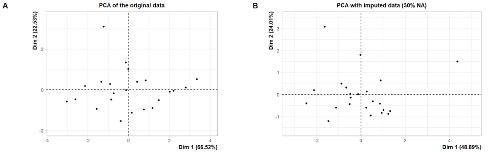

```r
pca_papillon_moy_30 = PCA(papillon_moy_30, graph=FALSE)
pca.compare.plot(pca,pca_papillon_moy_30, 'PCA with imputed data (30% NA)')
```

La qualité de l’imputation se dégrade (que ce soit vis à vis de la représentation sur le premier plan factoriel ou sur le poids des premiers composantes) en fonction du nombre de données manquantes malgré un regain de vraisemblance pour le jeu de données avec 20% de données manquantes.

## (5) Utiliser MissMDA pour imputer les données manquantes.

```r
library(missMDA)
```

```r
nb <- estim_ncpPCA(papillon_NA_5, scale=TRUE)
papillon_missMDA_5 <- imputePCA(papillon_NA_5, ncp=nb$ncp, scale = TRUE)

nb <- estim_ncpPCA(papillon_NA_15, scale=TRUE)
papillon_missMDA_15 <- imputePCA(papillon_NA_15, ncp=nb$ncp, scale = TRUE)
```

```r
nb <- estim_ncpPCA(papillon_NA_20, scale=TRUE)# ici ncp = 0
papillon_missMDA_20 <- imputePCA(papillon_NA_20, ncp=nb$ncp, scale = TRUE)

nb <- estim_ncpPCA(papillon_NA_25, scale=TRUE)
papillon_missMDA_25 <- imputePCA(papillon_NA_25, ncp=nb$ncp, scale = TRUE)

nb <- estim_ncpPCA(papillon_NA_30, scale=TRUE)
papillon_missMDA_30 <- imputePCA(papillon_NA_30, ncp=nb$ncp, scale = TRUE)
```

L’estimateur npcPCA indique que le nombre optimal de composante principales pour l’imputation est 0 : cette considération implique que cela revient à imputer les valeurs manquantes par la moyenne.

## (6) Application de l’ACP (missMDA)

- Appliquer l’ACP sur le jeu de données papillons

```r
pca = PCA(papillons, graph=FALSE)
```

- La fonction *pca.missMDA.compare.plot()*, créée ci-dessous, permet de comparer entre les différents plans factoriels après réalisation de l’ACP sur chaque tableau complété dans la partie suivante.

```r
pca.missMDA.compare.plot <- function(pca, pca.completed, titre){

  fig1 <- plot.PCA(pca, label='none', title='PCA of the original data')
  fig2 <- plot.PCA(pca.completed, label='none', title = titre)
  plot_grid(fig1, fig2, labels = "AUTO")

}
```

- Comparons les PCA avec imputation par la méthode missMDA et la PCA sur les données d’origine

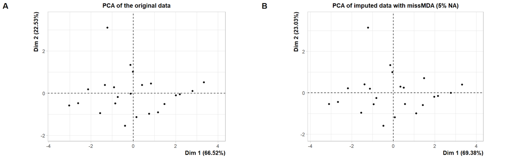

```r
pca_papillon_missMDA_5 <- PCA(papillon_missMDA_5$completeObs, graph=FALSE)
pca.missMDA.compare.plot(pca,pca_papillon_missMDA_5, 'PCA of imputed data with missMDA (5% NA)')
```

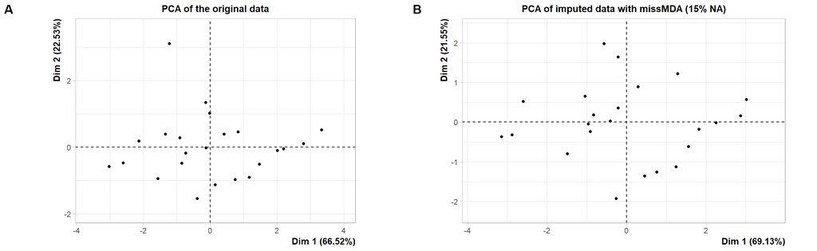

```r
pca_papillon_missMDA_15 = PCA(papillon_missMDA_15$completeObs, graph=FALSE)
pca.missMDA.compare.plot(pca,pca_papillon_missMDA_15, 'PCA of imputed data with missMDA (15% NA)')
```

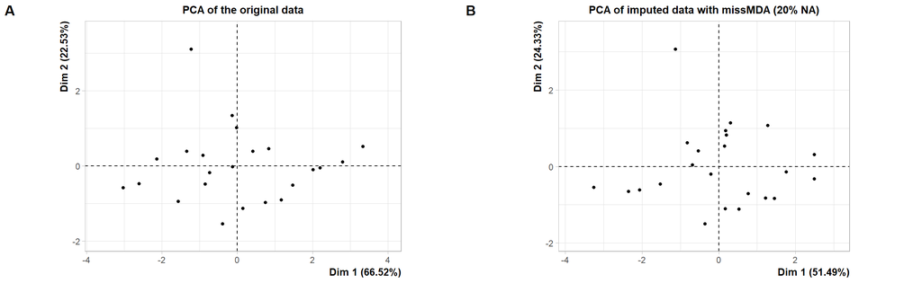

```r
pca_papillon_missMDA_20 = PCA(papillon_missMDA_20$completeObs, graph=FALSE)
pca.missMDA.compare.plot(pca,pca_papillon_missMDA_20, 'PCA of imputed data with missMDA (20% NA)')
```

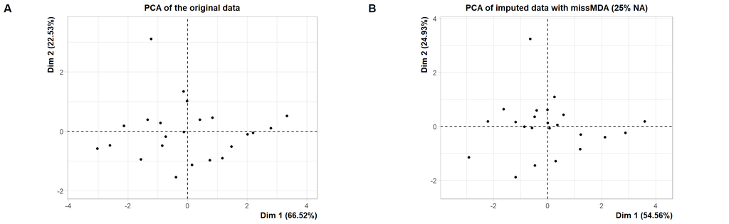

```r
pca_papillon_missMDA_25 = PCA(papillon_missMDA_25$completeObs, graph=FALSE)
pca.missMDA.compare.plot(pca,pca_papillon_missMDA_25, 'PCA of imputed data with missMDA (25% NA)')
```

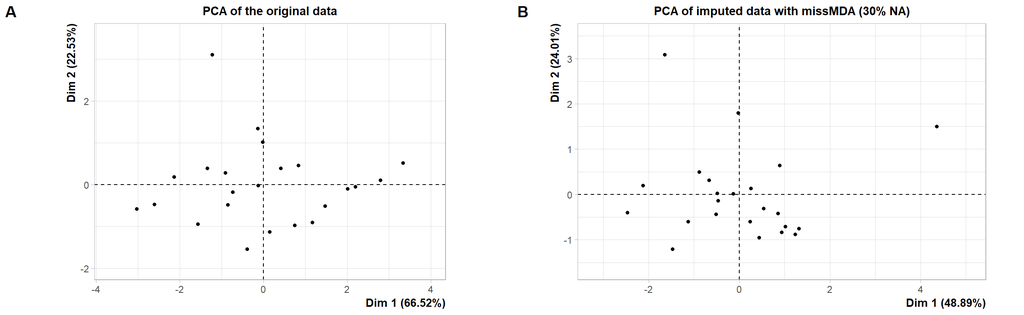

```r
pca_papillon_missMDA_30 = PCA(papillon_missMDA_30$completeObs, graph=FALSE)
pca.missMDA.compare.plot(pca,pca_papillon_missMDA_30, 'PCA of imputed data with missMDA (30% NA)')
```

Les résultats sont similaires à ceux présentés dans la partie 4.

**N.B.** Les résultats pour les imputations à 20, 25 et 30% sont les mêmes que pour l’imputation par la moyenne, comme expliqué en question (5)

## (7) Application de la méthode NIPALS

```r
library(plsdepot)
```

L’algorithme NIPALS permet de faire une analyse en composantes principales :

```r
pap.nipals = nipals(papillons,comps=2)
```

La méthode NIPALS repose sur cet algorithme et permet d’imputer les données manquantes.

```r
pap.nipals_5 = plsdepot::nipals(papillon_NA_5,comps=2)
pap.nipals_15 = plsdepot::nipals(papillon_NA_15,comps=2)
pap.nipals_20 = plsdepot::nipals(papillon_NA_20,comps=2)
pap.nipals_25 = plsdepot::nipals(papillon_NA_25,comps=2)
pap.nipals_30 = plsdepot::nipals(papillon_NA_30,comps=2)
```

On peut alors représenter les premiers plans factioriels pour chacunes des imputations.

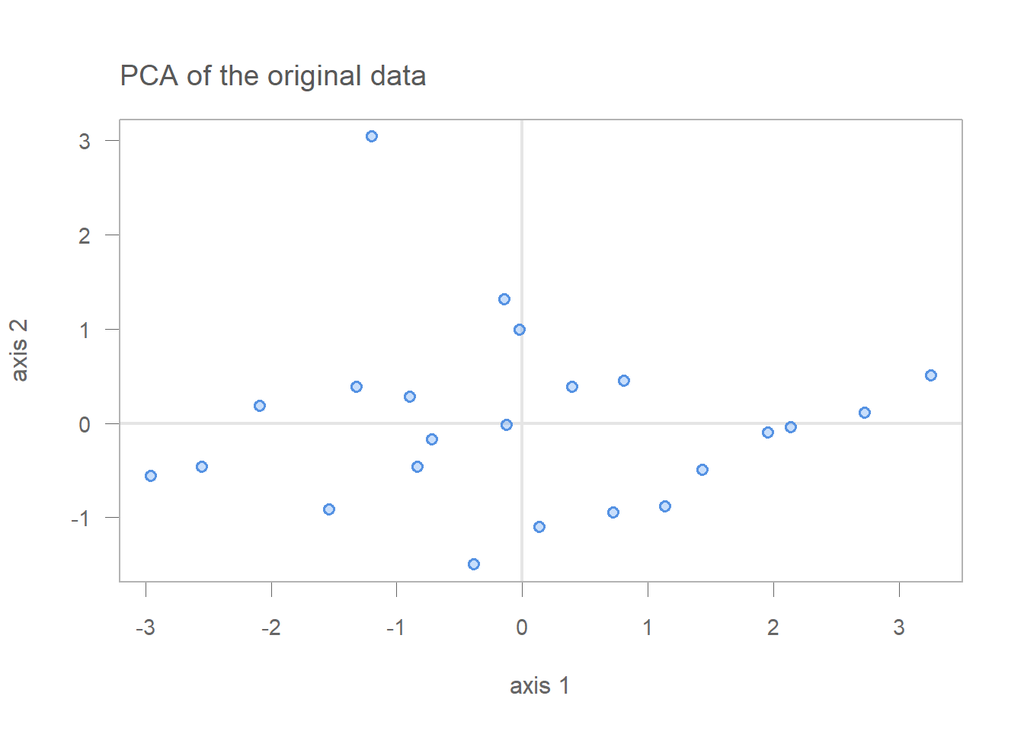

```r
plot(pap.nipals, what="observations", main='PCA of the original data')
```

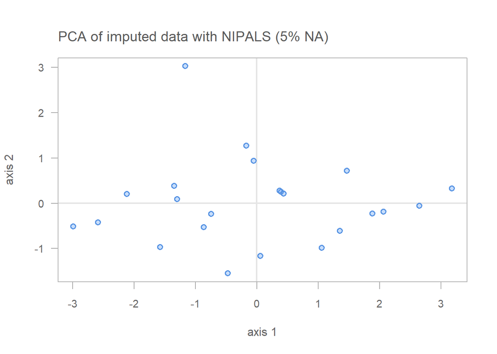

```r
plot(pap.nipals_5, what="observations", main='PCA of imputed data with NIPALS (5% NA)')
```

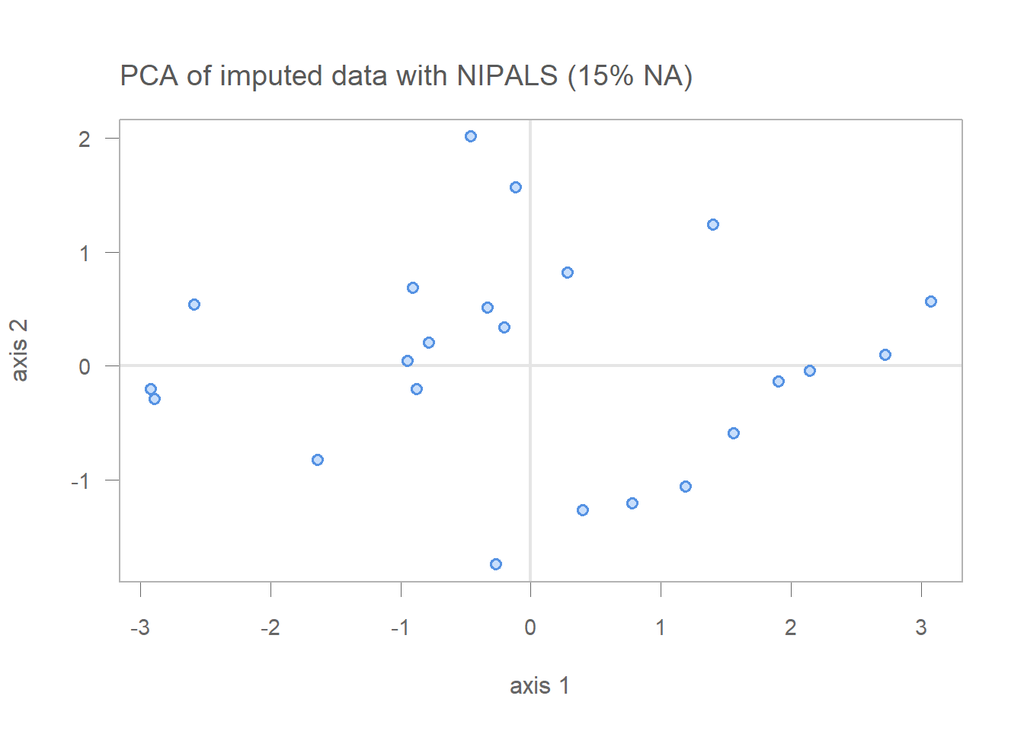

```r
plot(pap.nipals_15, what="observations", main='PCA of imputed data with NIPALS (15% NA)')
```

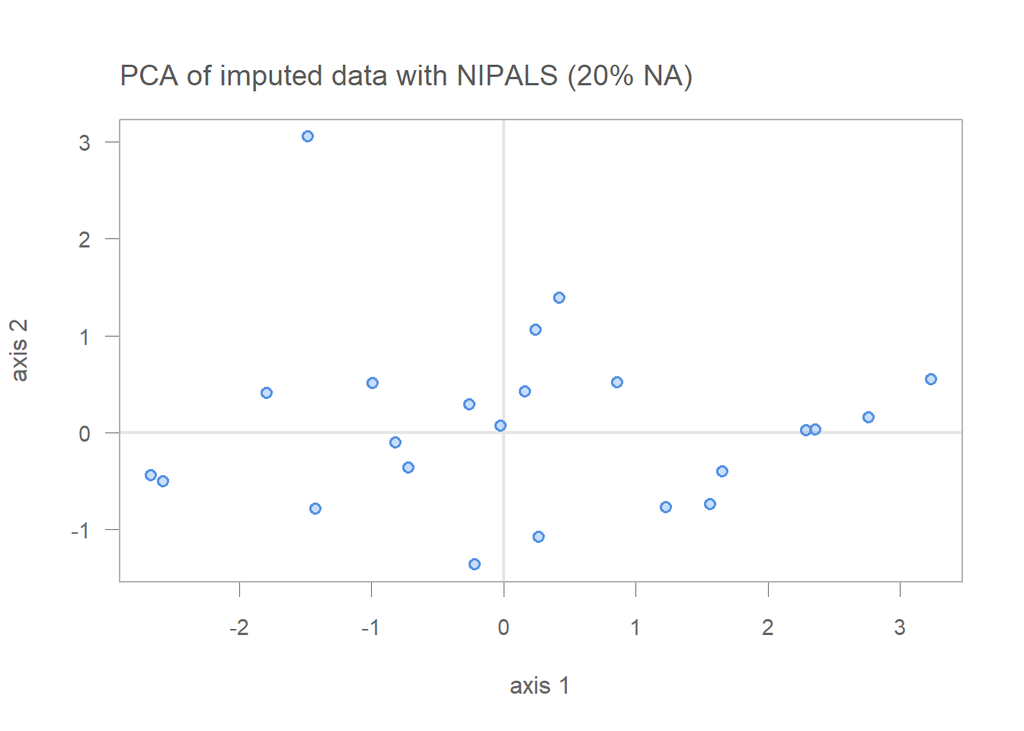

```r
plot(pap.nipals_20, what="observations", main='PCA of imputed data with NIPALS (20% NA)')
```

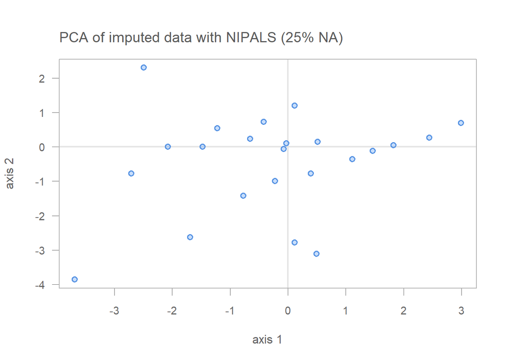

```r
plot(pap.nipals_25, what="observations", main='PCA of imputed data with NIPALS (25% NA)')
```

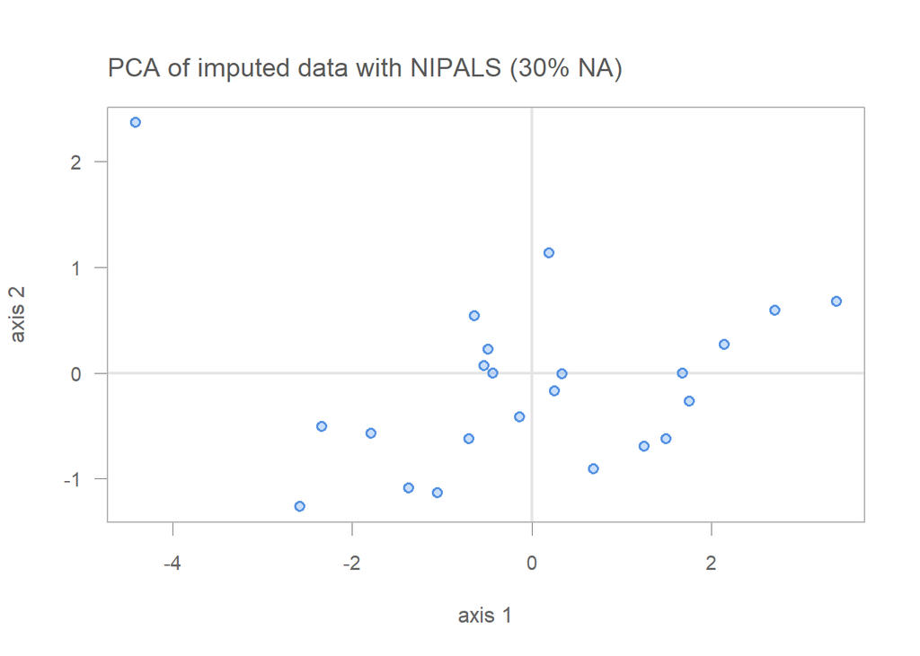

```r
plot(pap.nipals_30, what="observations", main='PCA of imputed data with NIPALS (30% NA)')
```

## (8)

Comparons la qualité des différentes imputations pour chacune des méthodes en fonctions des différents pourcentage de valeurs manquantes.

**N.B.** Nous utiliserons avant tout nipals du package ade4 pour récuperer les dataframes imputés (impossible via plsdepot)

```r
library(ade4)
```

```r
papillon_nipals_5 = ade4::nipals(papillon_NA_5, nf = 2, rec = TRUE)
# the option rec is needed to obtain the reconstitution of imputed data
# with NIPALS method
papillon_nipals_15 = ade4::nipals(papillon_NA_15, nf = 2, rec = TRUE)
papillon_nipals_20 = ade4::nipals(papillon_NA_20, nf = 2, rec = TRUE)
papillon_nipals_25 = ade4::nipals(papillon_NA_25, nf = 2, rec = TRUE)
papillon_nipals_30 = ade4::nipals(papillon_NA_30, nf = 2, rec = TRUE)
```

On décide de représenter les erreurs au sens des moindres carrés :

```r
imputation_error <- function(data, data_NA,imputed_data){
  # compute rmse between original values and imputed values on a dataframe
  bool = is.na(data_NA)
  rmse = sqrt(sum((data[bool]-imputed_data[bool])^2))
  return(rmse)
}
```

```r
# hold dataframe in list
NA_data = list(papillon_NA_5, papillon_NA_15, papillon_NA_20,
            papillon_NA_25,papillon_NA_30)

moy_data = list(papillon_moy_5, papillon_moy_15, papillon_moy_20,
              papillon_moy_25,papillon_moy_30)

missMDA_data = list(papillon_missMDA_5$completeObs, papillon_missMDA_15$completeObs,
                    papillon_missMDA_20$completeObs,papillon_missMDA_25$completeObs,
                    papillon_missMDA_30$completeObs)

nipals_data = list(papillon_nipals_5$rec, papillon_nipals_15$rec,
                   papillon_nipals_20$rec, papillon_nipals_25$rec,
                   papillon_nipals_30$rec)
```

Calculs des différentes erreurs :

```r
err.moy = c()
err.missMDA = c()
err.nipals = c()
for (i in 1:5){
  err.moy = c(err.moy, imputation_error(papillons,NA_data[[i]],moy_data[[i]]))
  err.missMDA = append(err.missMDA,
                       imputation_error(papillons,NA_data[[i]],missMDA_data[[i]]))
  err.nipals = append(err.nipals,
                      imputation_error(papillons,NA_data[[i]],nipals_data[[i]]))
}
```

[figure not shown]

```r
xdata = c(5,15,20,25,30)

# plot the first curve by calling plot() function
# First curve is plotted
plot(xdata, err.moy, type="o", col="blue", pch="o",
     lty=1, ylim=c(0,10), ylab="RMSE", xlab='Number of missing values (%)' )

# Add second curve to the same plot by calling points() and lines()
# Use symbol '*' for points.
#lines(xdata, err.nipals, col="red",lty=2)

# Add Third curve to the same plot by calling points() and lines()
# Use symbol '+' for points.
lines(xdata, err.missMDA, type="o", col="dark red", lty=2)

# Adding a legend inside box at the location (2,40) in graph coordinates.
# Note that the order of plots are maintained in the vectors of attributes.
legend(10,8,legend=c("Mean","MissMDA"), col=c("blue","dark red"),
                                   pch=c("o","o"),lty=c(1,2), ncol=1)
title(main='Imputation error with mean and MissMDA methods')
```

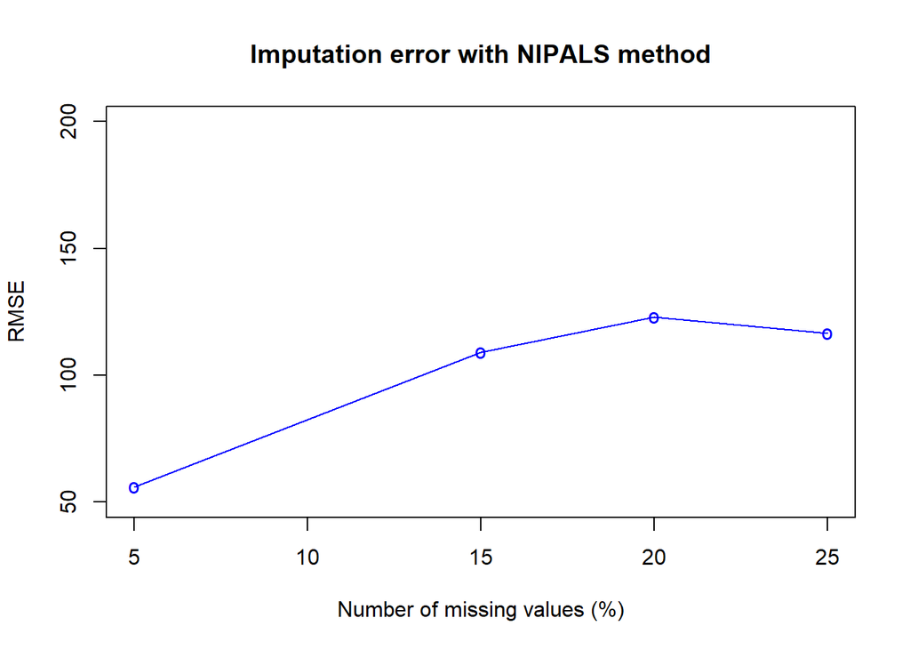

```r
plot(xdata[-5], err.nipals[-5], type="o", col="blue",
     pch="o", lty=1, ylim=c(50,200), ylab="RMSE", xlab='Number of missing values (%)' )
title(main='Imputation error with NIPALS method')
```

La robustesse de l’imputation peut alors être représenter celon le tableau suivant

```r
percentage_missingvalues <- c(5,15,20,25,30)
err.papillon <- data.frame(percentage_missingvalues,err.moy,err.missMDA, err.nipals)
err.papillon
```

```
##   percentage_missingvalues   err.moy err.missMDA err.nipals
## 1                        5  6.451036    5.718644   56.03591
## 2                       15 16.584672   14.062272  109.04430
## 3                       20 11.642085   11.642085  122.92424
## 4                       25 14.703051   14.703051  116.46455
## 5                       30 17.108307   17.108307  158.46587
```

# 2. Dataset: Paris 2005

## (10)

### 10 (1) Chargement du dataset et pré-traitement

```r
dat=read.table('Paris2005.txt')
```

Il est conseillé d’appliquer la transformation suivante sur notre jeu de données : en effet certaines méthodes d’imputations nécessite des jeux de données standardisées

```r
dat=log(dat+1)
```

### 10 (2) Génération des tableaux avec données manquantes

```r
dat_NA_5  <- get_missing_values(dat,0.05)
dat_NA_15 <- get_missing_values(dat,0.15)
dat_NA_20 <- get_missing_values(dat,0.20)
dat_NA_25 <- get_missing_values(dat,0.25)
dat_NA_30 <- get_missing_values(dat,0.30)
```

### 10 (3) Imputation par la moyenne

```r
dat_moy_5 =simple.impute.data.frame(dat_NA_5, fun=mean)
dat_moy_15 =simple.impute.data.frame(dat_NA_15, fun=mean)
dat_moy_20 =simple.impute.data.frame(dat_NA_20, fun=mean)
dat_moy_25 =simple.impute.data.frame(dat_NA_25, fun=mean)
dat_moy_30 =simple.impute.data.frame(dat_NA_30, fun=mean)
```

Les datasets ci dessus sont obtenus après imputation par la moyenne.

### 10 (4) Application de l’ACP

- Appliquer l’ACP sur le jeu de données Paris2005 après imputation par la moyenne

```r
pca = PCA(dat, graph=FALSE)
```

```r
pca.compare.plot <- function(pca, pca.completed, titre){

  fig1 <- plot.PCA(pca, label='none', title='PCA of the original data')
  fig2 <- plot.PCA(pca.completed, label='none', title = titre)
  plot_grid(fig1, fig2, labels = "AUTO")

}
```

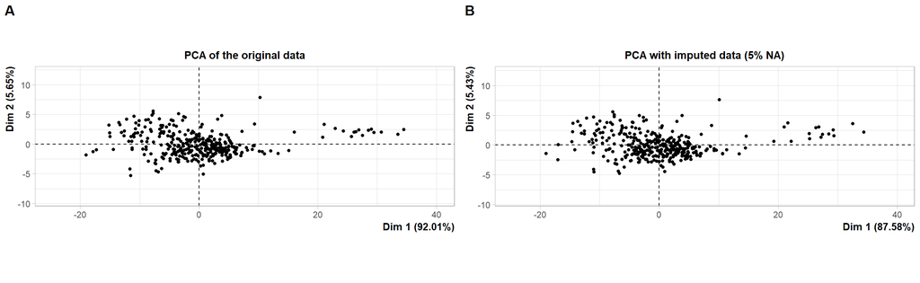

```r
pca_dat_moy_5 = PCA(dat_moy_5, graph=FALSE)
pca.compare.plot(pca,pca_dat_moy_5, 'PCA with imputed data (5% NA)')
```

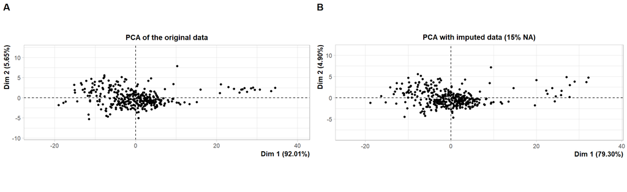

```r
pca_dat_moy_15 = PCA(dat_moy_15, graph=FALSE)
pca.compare.plot(pca,pca_dat_moy_15, 'PCA with imputed data (15% NA)')
```

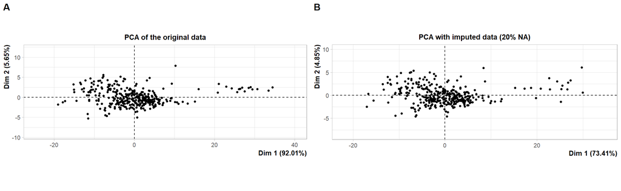

```r
pca_dat_moy_20 = PCA(dat_moy_20, graph=FALSE)
pca.compare.plot(pca,pca_dat_moy_20, 'PCA with imputed data (20% NA)')
```

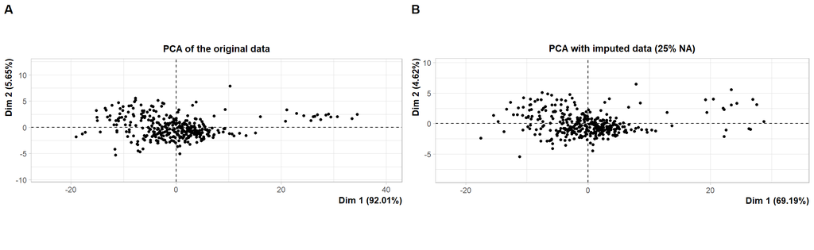

```r
pca_dat_moy_25 = PCA(dat_moy_25, graph=FALSE)
pca.compare.plot(pca,pca_dat_moy_25, 'PCA with imputed data (25% NA)')
```

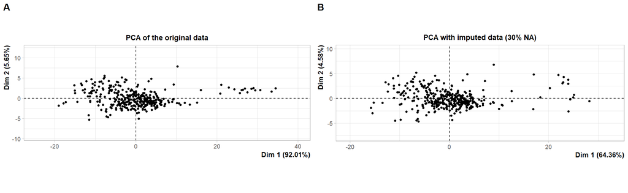

```r
pca_dat_moy_30 = PCA(dat_moy_30, graph=FALSE)
pca.compare.plot(pca,pca_dat_moy_30, 'PCA with imputed data (30% NA)')
```

### 10 (5) Utiliser MissMDA pour imputer les données manquantes.

```r
nb <- estim_ncpPCA(dat_NA_5, scale=TRUE)
dat_missMDA_5 <- imputePCA(dat_NA_5, ncp=nb$ncp, scale = TRUE)

nb <- estim_ncpPCA(dat_NA_15, scale=TRUE)
dat_missMDA_15 <- imputePCA(dat_NA_15, ncp=nb$ncp, scale = TRUE)

nb <- estim_ncpPCA(dat_NA_20, scale=TRUE)
dat_missMDA_20 <- imputePCA(dat_NA_20, ncp=nb$ncp, scale = TRUE)

nb <- estim_ncpPCA(dat_NA_25, scale=TRUE)
dat_missMDA_25 <- imputePCA(dat_NA_25, ncp=nb$ncp, scale = TRUE)

nb <- estim_ncpPCA(dat_NA_30, scale=TRUE)
dat_missMDA_30 <- imputePCA(dat_NA_30, ncp=nb$ncp, scale = TRUE)
```

### 10 (6) Application de l’ACP

On applique l’ACP sur le jeu de données Paris2005

```r
pca = PCA(dat, graph=FALSE)
```

```r
pca.missMDA.compare.plot <- function(pca, pca.completed, titre){

  fig1 <- plot.PCA(pca, label='none', title='PCA of the original data')
  fig2 <- plot.PCA(pca.completed, label='none', title = titre)
  plot_grid(fig1, fig2, labels = "AUTO")

}
```

Comparons les ACP :

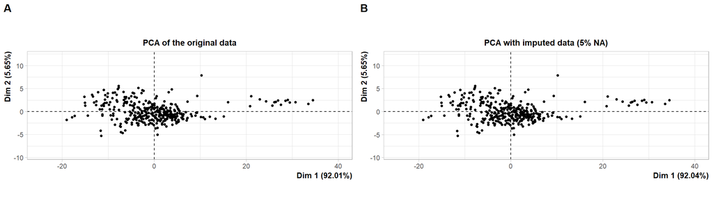

```r
pca_dat_missMDA_5 <- PCA(dat_missMDA_5$completeObs, graph=FALSE)
pca.missMDA.compare.plot(pca,pca_dat_missMDA_5, 'PCA with imputed data (5% NA)')
```

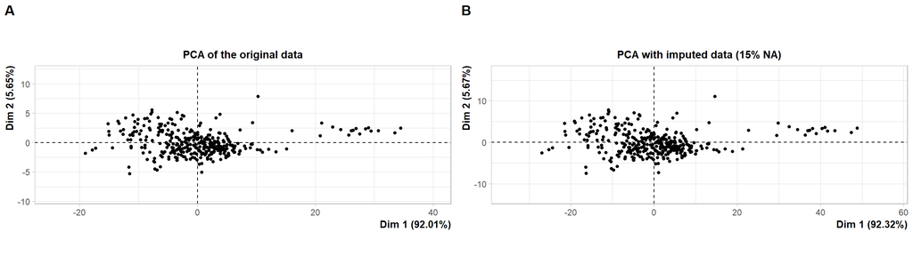

```r
pca_dat_missMDA_15 = PCA(dat_missMDA_15, graph=FALSE)
pca.missMDA.compare.plot(pca,pca_dat_missMDA_15, 'PCA with imputed data (15% NA)')
```

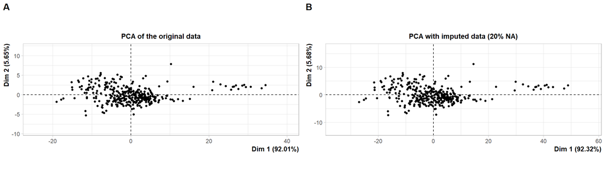

```r
pca_dat_missMDA_20 = PCA(dat_missMDA_20, graph=FALSE)
pca.missMDA.compare.plot(pca,pca_dat_missMDA_20, 'PCA with imputed data (20% NA)')
```

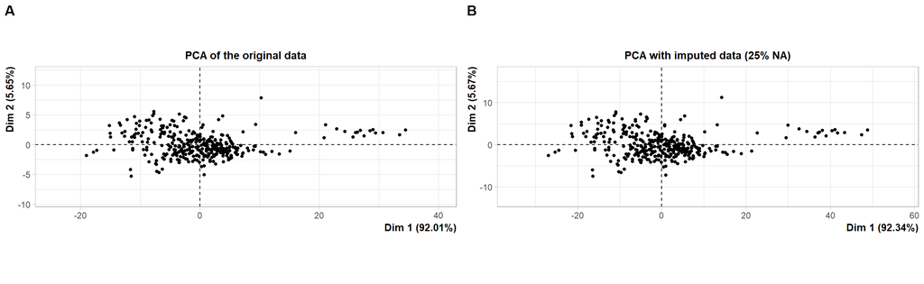

```r
pca_dat_missMDA_25 = PCA(dat_missMDA_25, graph=FALSE)
pca.missMDA.compare.plot(pca,pca_dat_missMDA_25, 'PCA with imputed data (25% NA)')
```

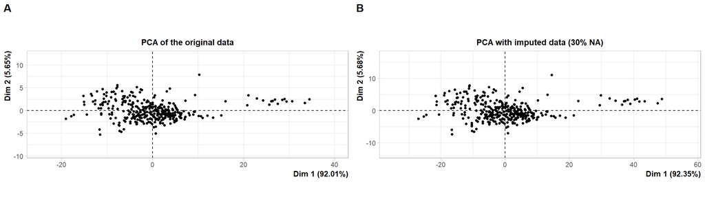

```r
pca_dat_missMDA_30 = PCA(dat_missMDA_30, graph=FALSE)
pca.missMDA.compare.plot(pca,pca_dat_missMDA_30, 'PCA with imputed data (30% NA)')
```